# Modelos bayesianos con rstan

Carlos J. Gil Bellosta

2016-02-11

# Pruebas de hipótesis clásicas

# Pruebas de hipótesis: el contexto

- Tiramos una moneda 100 veces y obtenemos 60 caras
- ¿Compatible con `p=.5`?
- Podemos hacer una prueba de hipótesis clásica con hipótesis nula ($H_0$): `p=0.5`
- De otra manera: ¿cómo de raras son 60 caras en 100 tiradas si `p=.5`?

# Prueba de hipótesis mediante remuestreos

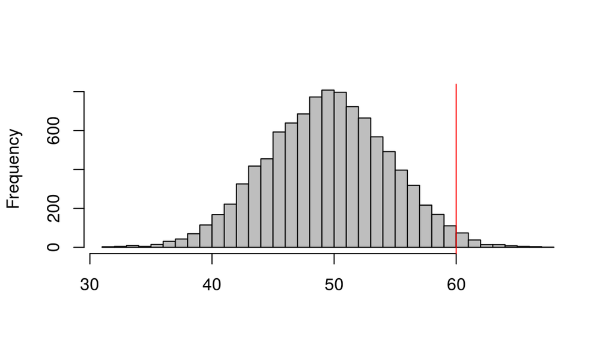

```r
N <- 100; n <- 60; p <- 0.5
muestras <- rbinom(10000, N, p)
hist(muestras, breaks = 30, col = "gray", main = "", xlab = "")
abline(v = n, col = "red")
```

# El p-valor: proporción de muestras que superan el valor obtenido

```r
mean(muestras >= n)
```

```
## [1] 0.0269
```

El p-valor es la proporción de muestras que exceden (en este caso) el valor obtenido.

Conceptualmente, es $P(D|H_0)$, la probabilidad de tus datos dada la hipótesis nula.

# Prueba de hipótesis como enseñan los libros

```r
binom.test(n, N, p, "greater")
```

```
##
##  Exact binomial test
##
## data:  n and N
## number of successes = 60, number of trials = 100, p-value =
## 0.02844
## alternative hypothesis: true probability of success is greater than 0.5
## 95 percent confidence interval:
##  0.5129758 1.0000000
## sample estimates:
## probability of success
##                    0.6
```

# Pruebas de hipótesis con rstan

# La perspectiva bayesiana

- No nos interesa $P(D | p)$ (el p-valor), sino, más bien, $P(p|D)$, es decir, la probabilidad del parámetro dados los datos.
- De otra manera, qué aprendemos sobre el parámetro a partir de la observación de unos datos.

# rstan: código

```r
library(rstan)

stanmodelcode <- '
data {
  int<lower=1> N;
  int n;
}

parameters {
  real<lower=0, upper = 1> p;
}

model {
  // priori no informativa
  p ~ beta(1,1);

  // verosimilitud
  n ~ binomial(N, p);
}
'

fit <- stan(model_code = stanmodelcode,
            data = list(N = 100, n = 60),
            iter=12000, warmup=2000,
            chains=4, thin=10)
```

# rstan: resultados

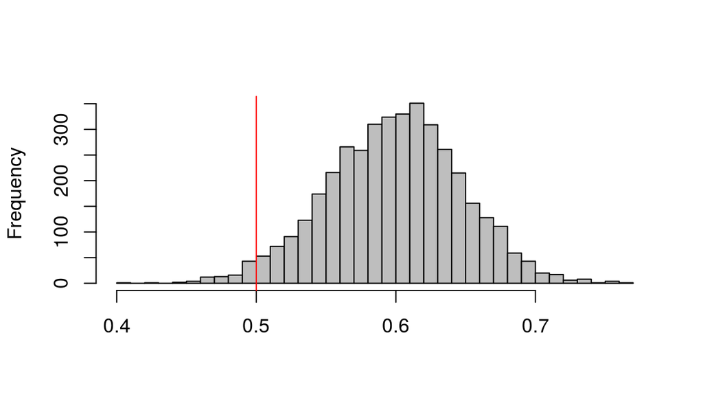

```r
res <- as.data.frame(fit)
hist(res$p, breaks = 30, col = "gray", main = "", xlab = "")
abline(v = 0.5, col = "red")
```

# Regresión lineal con rstan

# La solución tradicional

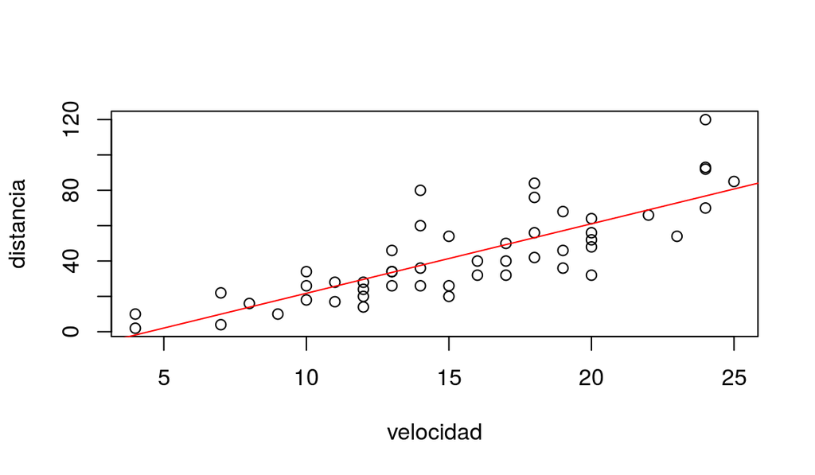

```r
modelo <- lm(dist ~ speed, data = cars)
plot(cars$speed, cars$dist, xlab = "velocidad", ylab = "distancia", main = "")
abline(modelo, col = "red")
```

# La solución tradicional: coeficientes, etc.

```
##
## Call:
## lm(formula = dist ~ speed, data = cars)
##
## Residuals:
##     Min      1Q  Median      3Q     Max
## -29.069  -9.525  -2.272   9.215  43.201
##
## Coefficients:
##             Estimate Std. Error t value Pr(>|t|)
## (Intercept) -17.5791     6.7584  -2.601   0.0123 *
## speed         3.9324     0.4155   9.464 1.49e-12 ***
## ---
## Signif. codes:  0 '***' 0.001 '**' 0.01 '*' 0.05 '.' 0.1 ' ' 1
##
## Residual standard error: 15.38 on 48 degrees of freedom
## Multiple R-squared:  0.6511, Adjusted R-squared:  0.6438
## F-statistic: 89.57 on 1 and 48 DF,  p-value: 1.49e-12
```

# rstan: código

```r
stanmodelcode <- '
data {
  int N;
  vector[N] speed;
  vector[N] dist;
}

parameters {
  real a0;
  real a1;
  real<lower = 0, upper = 100> sigma;
}

model {
  // prioris
  a0 ~ cauchy(0, 100);
  a1 ~ cauchy(0, 100);
  sigma ~ cauchy(0, 5);

  // verosimilitud
  for (i in 1:N)
    dist[i] ~ normal(a0 + a1 * speed[i], sigma);
}
'

fit <- stan(model_code = stanmodelcode,
            data = list(N = nrow(cars), speed = cars$speed, dist = cars$dist),
            iter=12000, warmup=2000,
            chains=4, thin=10)
```

# rstan: resultados

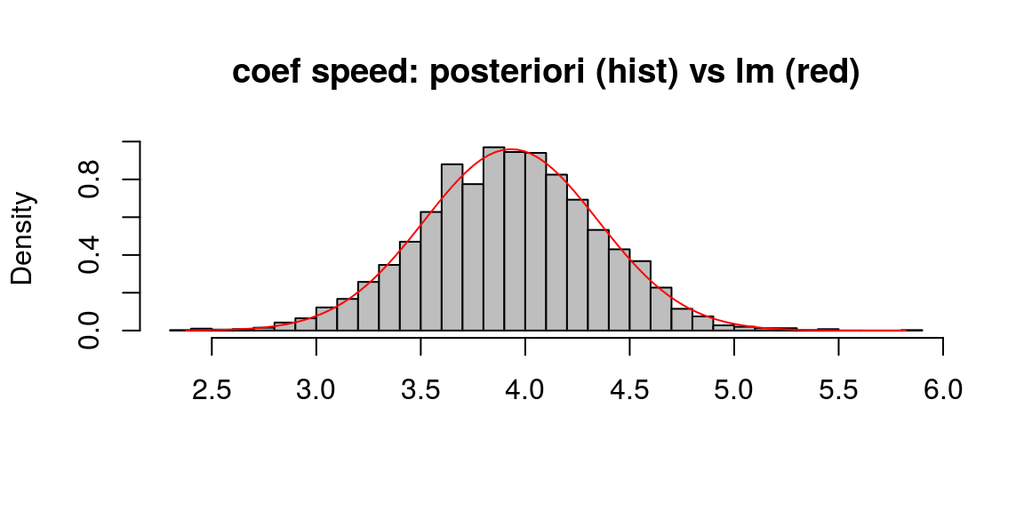

```r
tmp <- as.data.frame(fit)$a1
hist(tmp, breaks = 30, col = "gray", xlab = "", freq = FALSE,
     main = "coef speed: posteriori (hist) vs lm (red)")
coefs <- summary(modelo)$coefficients[2,]
curve(dnorm(x, coefs[1], coefs[2]), from = min(tmp), to = max(tmp), col = "red", add = TRUE)
```

# rstan: resultados

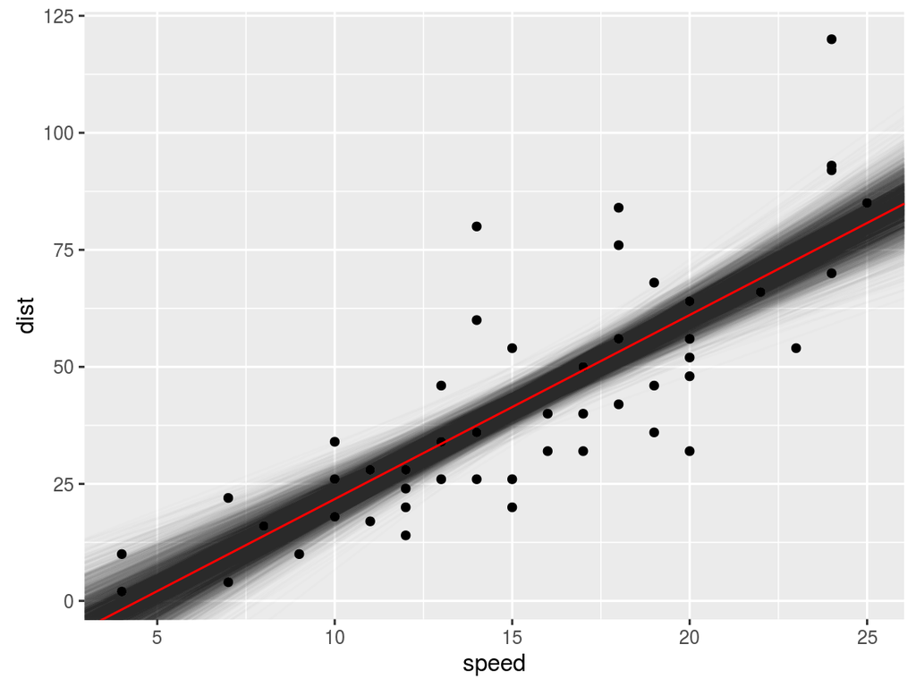

```r
library(ggplot2)
tmp <- as.data.frame(fit)[, c("a0", "a1")]
ggplot(cars, aes(x = speed, y = dist)) + geom_point() +
  geom_abline(data = tmp, aes(slope = a1, intercept = a0), alpha = 0.01) +
  geom_abline(intercept = coef(modelo)[1], slope = coef(modelo)[2], col = "red")
```

# rstanarm: rstan para todos

```r
library(rstanarm)

post <- stan_lm(dist ~ speed, data = cars,
                prior = R2(location = 0.5, what = "median"),
                chains = 4, cores = 4, seed = 1234)
```

- Incluye funciones para versiones *estanizadas* de `lm`, `glm`, `lmer`, etc.
- Son más robustos, según los autores, que los que uno pueda construir *a mano*
- Sobre todo, permiten especificar modelos con la interfaz habitual (con fórmulas)

# Modelos de series temporales estructurales (filtro de Kalman)

# Modelo clásico

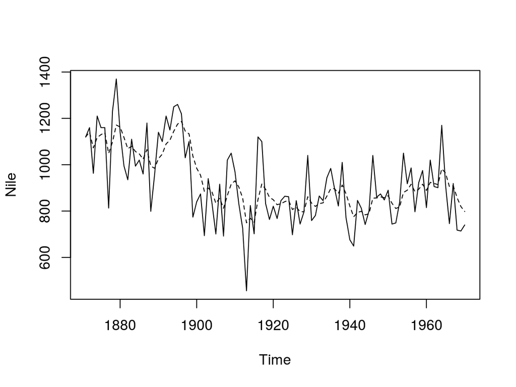

```r
plot(Nile)

fit <- StructTS(Nile, type = "level")
lines(fitted(fit), lty = 2)
```

# Las matemáticas subyacentes

Tenemos un proceso subyacente *real*

$m_{t+1} = m_t + \epsilon_t$, donde $\epsilon_t \sim N(0, \sigma_0)$

y observaciones (los datos) *generados* por el proceso subyacente mediante

$x_t = m_t + \eta_t$, donde $\eta_t \sim N(0, \sigma_1)$

# El modelo

```r
codigo <- '
data {
  int N;
  vector[N] nilo;
}

parameters {
  vector[N] m;
  real<lower=0, upper = 1000> sigma0;
  real<lower=0, upper = 1000> sigma1;
}

model {
  for (i in 1:N)
    m[i] ~ normal(1000, 500);

  nilo[1] ~ normal(m[1], sigma1);

  for (i in 2:N){
    m[i]    ~ normal(m[i-1], sigma0);
    nilo[i] ~ normal(m[i], sigma1);
  }
}
'

fit <- stan(model_code = codigo,
            data = list(N = length(Nile), nilo = as.vector(Nile)),
            iter=12000, warmup=2000,
            chains=4, thin=10)
```

# Resultados: 4000 trayectorias simuladas

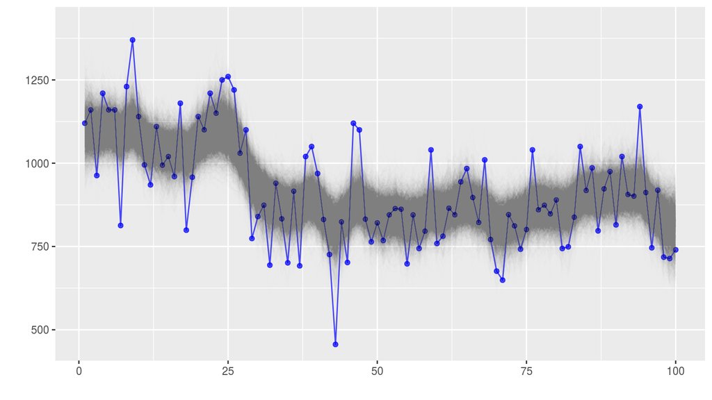